# ds-stats-aiml

**Data Science vs. Statistics vs. AI vs. Machine Learning: A Comparative Overview**

**Robert Daniels**

*Data Scientist and Statistician*

## License

This presentation is licensed under the [Creative Commons Attribution-ShareAlike 4.0 International License (CC BY-SA 4.0)](https://creativecommons.org/licenses/by-sa/4.0/).

Please give appropriate credit if you reuse or adapt this work.

## Who I am

Rob Daniels, MS, MPH, CPH

Experience: 13+ years in applied statistics, data science, machine learning

Former roles:

- Statistician at Harvard University
- Contractor statistician at Centers for Disease Control and Prevention (CDC)

## Overview

- Distinguish between AI, machine learning, data science, and statistics
- Distinguish statistical models (SM) vs. machine learning models (ML)
- Guidelines on when and how to apply SM vs. ML

## AI vs. machine learning vs. data science vs. statistics

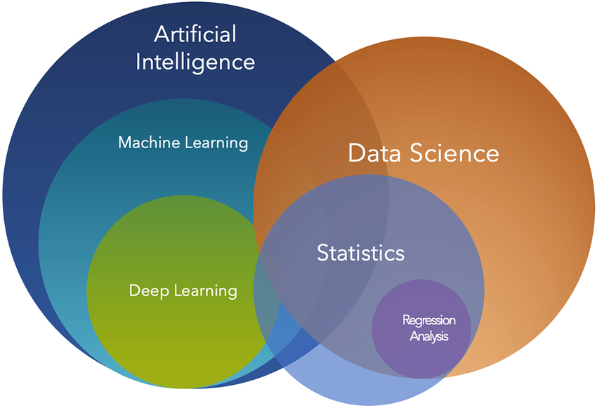

Morris et al. (2024). Current and future applications of artificial intelligence in surgery: implications for clinical practice and research. *Frontiers in Surgery, 11*. https://doi.org/10.3389/fsurg.2024.1393898.

## Artificial intelligence (AI)

**Simulation of human intelligence** in machines that are programmed to think, learn, and make decisions

**Artificial narrow intelligence (ANI)**  
• “One-trick-pony” applications  
• E.g., smart speaker, self-driving car, web search

**Generative AI**  
• More general-purpose uses  
• E.g., ChatGPT, Claude, Gemini, DeepSeek, DALL-E 2

“You won’t lose your job to AI, but you may lose your job to someone who knows how to use AI”

**Agentic AI**  
• More autonomous decisions/actions  
• E.g., OpenAI’s Operator

**Artificial general intelligence (AGI)**  
• Anything a human can do

Ng, A. (2021). What is AI? [Video lecture]. *AI for Everyone*. Coursera. https://www.coursera.org/learn/ai-for-everyone

## What is machine learning?

“The science of getting computers to learn without being explicitly programmed”

**Supervised learning**  
• Maps input to output: X → Y labels  
• Classification, regression, neural networks

*Examples:*  
– X-ray image → tumor/no tumor  
– Words → next word (LLM)

**Unsupervised learning**  
• No labels  
• Clustering, anomaly detection, data reduction

*Examples:*  
– Customer segmentation  
– Fraud detection

**Reinforcement learning**  
• Rewards and punishments guide learning

*Examples:*  
– Self-driving cars  
– Robotics

## Deep learning

- Subset of machine learning using multi-layered neural networks to model complex patterns
- Commonly used types of NN:
- Recurrent neural networks (RNN) (natural language processing, speech recognition)
- Generative adversarial networks (GANs) (image generation, style transfer)
- Convolutional neural networks (CNNs) (image processing, object detection)

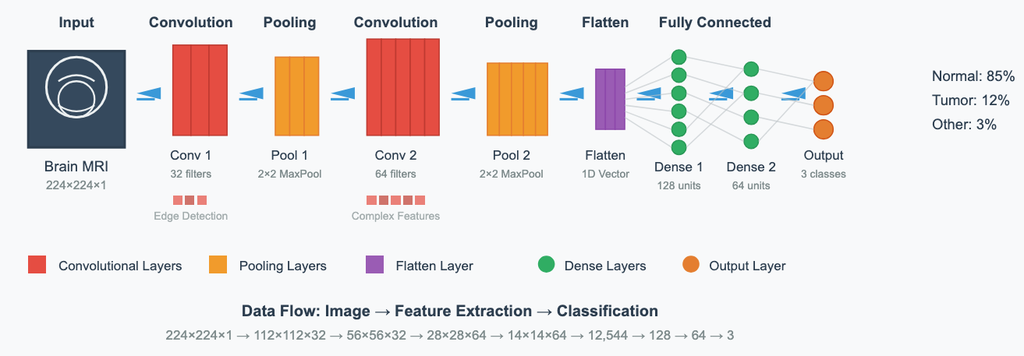

Convolutional neural network diagram created by Claude AI (Anthropic, 2025). https://claude.ai.

Data Science

Statistics

Scope

- Broader, multi-disciplinary
- Integrates computer science, data analysis, ML, data visualization, and domain knowledge
- Narrower; focused on theory and methods for collecting, analyzing, interpreting, and presenting data
- Emphasizes understanding relationships and uncertainty in data

Core principles

- Algorithm-based
- Prediction-focused
- Inference, hypothesis testing, estimation
- Rooted in probability and mathematical rigor

Problem-solving approach

- Exploratory, iterative
- Optimizing predictions
- Usually hypothesis-driven
- Emphasis on testing and validating assumptions

(1/2)

Data Science

Statistics

Tools and techniques

- More programming (e.g., Python, SQL)
- ML, deep learning, big data tools (e.g., Spark)
- Specialized statistical software (e.g., R, SAS, Stata, Mplus)
- Specialized methods (e.g., mixed modeling)

Data

- Large-scale
- Unstructured, semi-structured, and structured
- Primarily structured
- Smaller samples, well-defined study designs

Applications

- Tech industry, business intelligence
- Fraud detection, NLP, computer vision
- Clinical trials
- Survey analysis, data collection, risk modeling

(2/2)

## Statistics vs. machine learning

## Inference vs. prediction

- Inference involves drawing conclusions about a population based on a sample of data; it is concerned with understanding relationships, estimating parameters, and testing hypotheses
  - Focuses on why something happens
  - E.g., identifying which factors significantly impact disease risk
- Prediction refers to using a model to forecast future outcomes based on current or historical data
  - Focuses on what will happen
  - E.g., predicting whether a patient will develop a disease given a set of health metrics
- Traditional statistical models are typically designed for inference and focus on interpretability but can do both inference and prediction
- Machine learning models optimize prediction and offer limited inference

## Statistical models vs. machine learning models

- Statistical models are probabilistic and explicitly consider uncertainty
- Statistical models start with preconceived structure and typically assume additivity of predictor effects when specifying the model
- Machine learning models are more empirical and allow for higher-order interactions that are not pre-specified; do not attempt to isolate the effect of any single variable

Harrell, Frank. (2018, April 30). Road map for choosing between statistical modeling and machine learning. *Statistical Thinking*. https://www.fharrell.com/post/stat-ml/.

## When to use SM vs. ML

- ML may work best when overall prediction is the goal without being able to describe the impact of any one predictor
- ML requires large sample sizes (typically 200 events per candidate predictor)
- ML might work better for high signal-to-noise situations (e.g., visual and sound recognition)
- ML tends to work well when learning a simple concept
- ML tends to work poorly when:
  - Learning complex concepts from small amounts of data
  - Performs on new types of data (data the model was not trained on)

Harrell, Frank. (2018, April 30). Road map for choosing between statistical modeling and machine learning. *Statistical Thinking*. https://www.fharrell.com/post/stat-ml/.

## Additional AI/ML considerations

## AI/ML roles

- Data scientist
- ML engineer (also new: AI engineer)
- Data engineer
  - Organize and manage data, data access, security in a cost-effective way
  - Needed for project with large data (≥ TB)
- AI product manager
- Training resources:
  - Emphasis on concepts and algorithms not just specific AI implementations

## One second rule

| **What is it?** | *If a human can complete a task in about one second of thought, AI may be able to automate it* |
| --- | --- |

| **Why it works** | • Pattern recognition: AI learns from data like human intuition • Low complexity: quick decisions are ideal for AI • Automation potential: repetitive, structured tasks fit well |
| --- | --- |
| **Examples** | • Object recognition in images • Text prediction • Document classification |
| **When the rule breaks down** | • Deep reasoning required • Ambiguity and subjectivity |

## Considerations for LLMs

- Retrieval-augmented generation (RAG)
  - Combines an existing LLM with a custom knowledge base to provide up-to-date domain specific answers
- Fine-tuning pre-trained models
  - Requires less data and compute power than training from scratch
  - Uses existing models that are fine-tuned on domain-specific data